# Normal Distribution

Bernard Ade

01-02-2017

Normal distribution is a type of probability distribution. In statistics, there are several types of distributions that displays all possible values of a variable and how often values occurs. Normal distributon is the most common of all these distributions. There are many phenomenoms that follow a normal distribution such as the height of people, test scores, manufacturing production processes etc

**Some important properties of a normal distribution include:**

- The mean, median and mode equals the center of the curve.
- The total area under the curve equals one.
- The shape of the curve is symmetrical which implies that if you split the curve straight down the middle each half of the curve equals .5
- The normal curve approaches but never touches the x-axis

##### Question

We can use R to calculate probability of a normal disitribution. Suppose you took a qualifying test where only those in the top 10 percent qualified. When the scores were released you discovered that your score is 1215, you also learned that the scores are normally distributed with a mean of 750 and standard deviation of 280. Lets use a probability distribution plot to find your percentile of score.

```r
pnorm(1215, mean = 750, sd = 280, lower.tail = T)
```

```
[1] 0.9516146
```

##### Lets visualize the normal distribution.

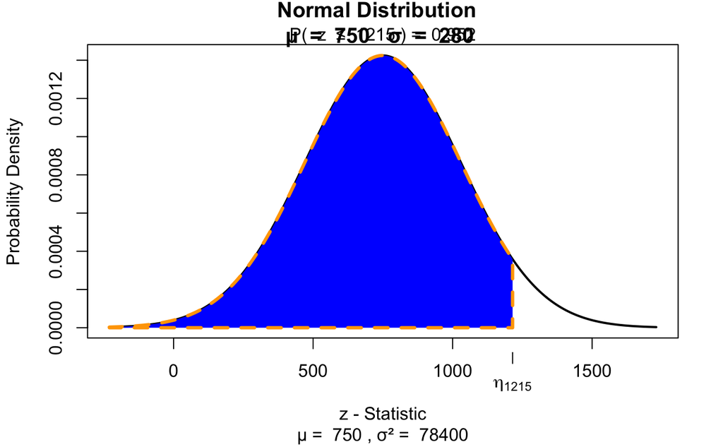

```r
library(visualize)
visualize.norm(stat = 1215, mu = 750, sd = 280, "lower")
```

Based on a normal distribution with a mean of 750 and a standard deviation of 280, 95% of scores are less than or equal to the score of 1215. Therefore, the score of 1215 at the 95th percentile qualifies from testing.

The focus here as usual is on concept and intuition. The **intuition** here is to understand the behaviour of how sampling distributions paves the way for drawing inference and finding probability of ranges of possible outcomes.

Here are some resources for diving deep.

[Introduction to the normal distribution | Probability and Statistics | Khan Academy](https://www.youtube.com/watch?v=hgtMWR3TFnY&t=588s)

[Normal Distribution, Z Scores, and Normal Probabilities in R](https://www.youtube.com/watch?v=hgtMWR3TFnY&t=588s)